# Hours Progression in the UK

25 July 2019

## Introduction

- 22% of the UK population live in poverty (JRF, 2018).
- 67% of adults living in poverty reside in households where at least one individual is in work (JRF, 2018).
- The majority of low paid jobs are held by part-time employees (Resolution Foundation, 2019).
- Part-time employees are frequently primary or sole earners in their household.
- One in eight part-time workers reports wanting to work more hours (ONS, 2018).
- Decreasing in-work poverty rates appears to be a case of increasing both pay **and** hours.

## Introduction

- Most research addresses this problem from angle of low hourly pay, rather than few working hours.
  - Exceptions include Cai et al. (2014)
- For instance, Cai et al. (2018) look at the transition probabilities from low paid work to high-paid work to assess whether low pay is a stepping stone or a trap.
  - See also Cappellari and Jenkins (2008a, 2008b), Fok et al (2015) and Cai (2014).
- Here, we look at progression from part-time paid employment to full-time paid employment
- This also has relevance to the DWP given conditionality requirements in Universal Credit.

## Introduction

- Most work on low pay looks at single transitions, rather than sustained change (e.g., Cai et al., 2018)
- The Resolution Foundation (2017) adopt a different approach, tracking a cohort of low paid individuals over ten years to see how many “escape” or remain “stuck”.
  - Trajectories grouped using logical rules.
  - For instance, escape defined as high paid in each of final three years.
- But, the logical rule approach can be arbitrary and infeasible.
  - With 3 states (no-pay/low-pay/high-pay) and 10 time periods, there are 59,049 possible sequences.
  - Why not high paid in each of final two years?

## Introduction

- Here we use **Sequence Analysis** to categorise labour market trajectories over 36 months after leaving part-time paid employment.
- Sequence Analysis uses information within the labour market trajectories themselves to group similar trajectories together.
- With this we can:
  - assess what the **typical** experiences are after leaving part-time employment
  - explore the characteristics of the individuals having these experiences.
- In short, we can:
  - distinguish **sustained** transitions from short-term transitions
  - create more flexible categories for other typical labour market experiences.

## Introduction

- To explore which characteristics are associated with different trajectory *types*, I combine Sequence Analysis with Multistate Modelling using the SAMM method developed by Studer et al. (2018).
- Specifically, I take 36 month subsequences initiated by a transition from part-time **paid** employment to another labour market state.
- Then, I group similar sequences together using sequence analysis.
- Finally, I run a set of Cox models with the groups defining the events.
  - i.e. I predict the harzard rate of exiting part-time employment into a particular trajectory *type*.

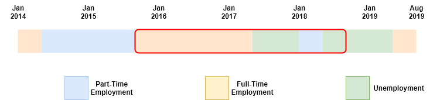

## Introduction

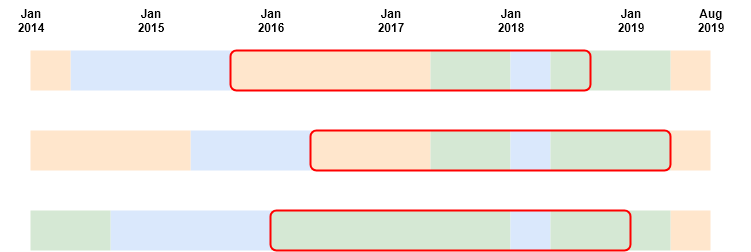

## Introduction

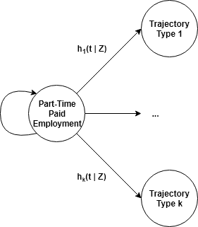

## Data

- British Household Panel Survey (BHPS) and Understanding Society (UKHLS).
- Data runs from 1991-2018 (26 waves overall).
- Household panel surveys with individuals interviewed each year.
- Panel is unbalanced: individual enter and exit at different times.
- At first interview, participants asked for start date of current job.
- At succeeding interviews, participants asked for dates of changes in employment status since previous interview.
- From this, we construct a monthly labour market trajectory from start of initial job to end of follow-up.

## Data

- We limit to those with part-time *paid* employment spells.
- We exclude spells begun before age 18 to (partly) remove summer jobs or jobs held alongside education.
- We stop follow-up at age 60 to exclude those of retirement age.
  - Mistake: should be 57.
- There are four issues with this data:
  - Seam effects
  - Spurious transitions
  - Measurement error
  - Selection bias for initial jobs

## Methods: Sequence Analysis

- Sequence Analysis involves two steps.
- In the first step, a matrix of “dissimilarties” is created containing a measure of dissimilarity for each pair of sequences in the data.
- Many algorithms for measuring dissimilarity exist.
  - See Studer and Ritschard (2016) for a review
- Here we use Optimal Matching (OM).
- In OM, the distance between two sequences is the number of operations required to convert one sequence into the other.
- Operations are insertions, deletions, and substitutions of states.

## Methods: Sequence Analysis

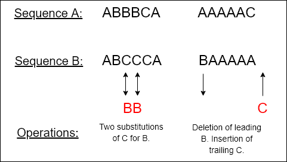

## Methods: Sequence Analysis

- Operations are also assigned a **cost** to distinguish between different operations.
- For instance, a substitution between unemployed and inactive may be assigned a lower cost than unemployed and full-time work as these are more qualitatively similar.
- There are many ways of setting costs
  - See Studer and Ritschard (2016) for a review.
- Here we use transition probabilities.
- A substitution between two states has a higher cost if there are few transitions between the two states observed in the data.
- Note, different cost functions - and different dissimilarity algorithms - can produce different results from the data (Piccarreta and Studer, In Press).

## Methods: Sequence Analysis

- The second step is to use a clustering algorithm to extract groups of similar sequences from the dissimilarity matrix.
- Standard cluster analysis algorithms can be used.
- I use the Partioning Around Medoid (PAM) method.
- To extract *k* clusters, PAM first selects *k* partitioning observations and places remaining observations in a cluster with closest partitioning observation.
- Partitioning observations then swapped until within cluster variance is minimised.

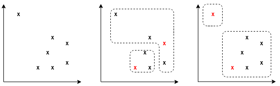

## Methods: Sequence Analysis

- I carry out sequence analysis for transitions to full-time work and to other states, separately.
- I run PAM for k from 2 to 20 in each case.
- I select final k based on visual inspection of index plots and Average Silhouette Width (ASW) measure.
- ASW captures degree to which observations are similar within clusters and dissimilar across clusters.
- ASW is bounded between -1 and 1. Kaufman and Rousseeuw (1990) propose following rules:
  - 0.71 - 1.0: Strong structure
  - 0.51 - 0.7: Reasonable structure
  - 0.26 - 0.5: Weak, potentially artifical, structure
  - <= 0.25: No structure.

## Methods: Sequence Analysis

- ASW alone is not sufficient to choose correct numbers of clusters.
- Qualitative assessment also required to make sure clusters are meaniningful (Piccarreta and Studer, In Press).

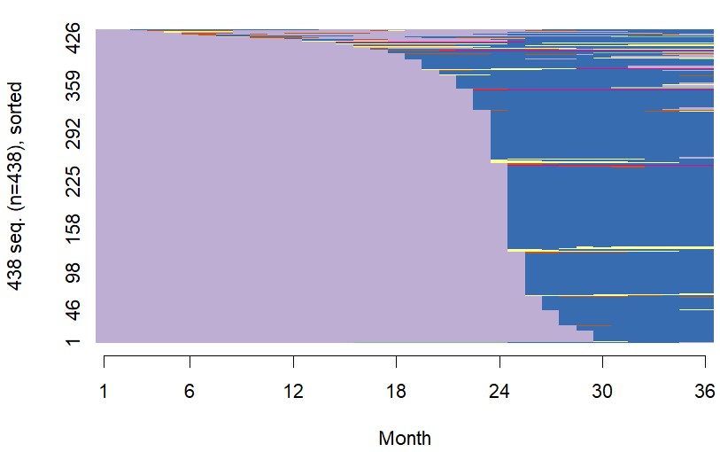

## Methods: SAMM

- The result of the Sequence Analysis is a categorical variable which groups similar trajectories together.
- This variable can be used an any other variable.
  - An independent variable to predict some outcome (e.g. association between trajectory and later mental health).
  - A dependent variable to be predicted by some other variables (e.g differences in trajectories by gender/age).
- Here, we use the clusters to define events in a multistate model.
- Specifically, we estimate a set of Cox models where the event is a transition from part-time employment into one of the trajectory *types*.

## Methods: SAMM

- In a given Cox model, the data are coded as censored if:
  - An individual does not exit part-time employment by end of follow up
  - An individual exits within the final three years
  - An individual exits into a different trajectory type.
- This is a Competing Risks style set up.
- Exit from part-time employment into one trajectory type precludes moving into another trajectory type.

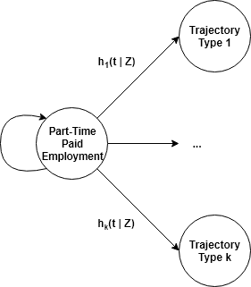

## Methods: Model Covariates

- I use the multistate model to predict the *hazard* of exiting part-time employment into different trajectory types.
- I add several variables to these models to assess how the hazard rate differs across groups of individuals.
- In particular, I add information on:
  - Gender
  - Age (grouped)
  - Educational attainment
  - Parent of a child under 16
  - Ethnicity
  - UK-wide unemployment rate
  - Pre/Post introduction of National Minimum Wage.
- Limited by variables that are fixed or measured monthly.

## Methods: Model Covariates

- To explore differences by gender, I add interactions between sex and age, education and parenthood.
- As individuals may have multiple spells, I add a random effect (frailty term) for individual.
- I also add random effect for year.
- Note, because of data collection procedure, the sample is biased towards long spells and spells that last longer in earlier years.
- By definition, I only observe spells before first interview if they are continuing.

## Methods: Model Covariates

- To (attempt to) get around this, I add indicator variables for:
  - Whether spell began before first interview
  - Whether current month is before first interview
- Data is interval coded (left and right censored) with one observation for each month a part-time spell lasts.
- Note, I cannot just exclude initial jobs because this creates bias in opposite direction.
- Suggestions welcome.

## Methods: Software, etc.

- Data unweighted due to unbalancedness of panel.
- Complete case analysis only as standard software doesn’t exist to impute missing sequence data for unbalanced panels.
- Data cleaned in Stata.
- Analysis carried out in R using TraMineR (Gabadinho et al., 2015) and WeightedCluster (Studer, 2013) packages for sequence analysis and coxme (Therneau, 2019) package for mixed-effects Cox models.
- Code adapted from that provided by Matthias Studer. Email me for liam.wright.17@ucl.ac.uk.

## Results: Descriptive Statistics

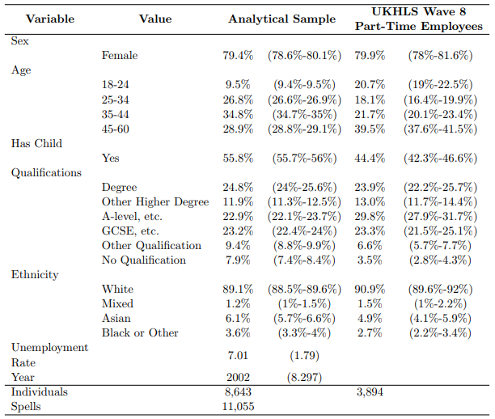

## Results: Descriptive Statistics

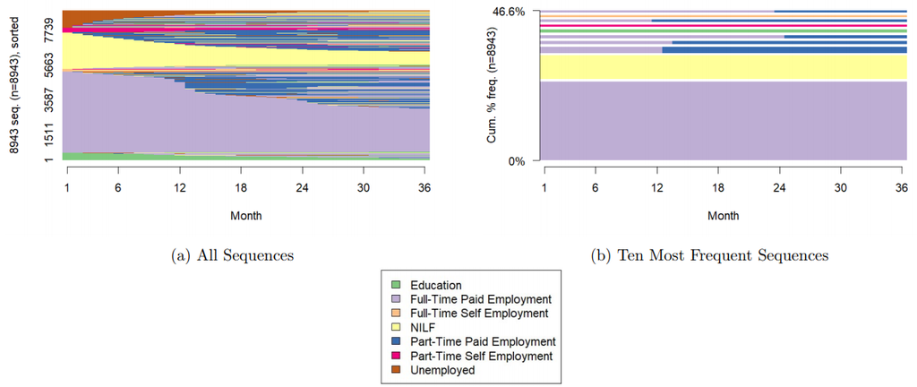

## Results: Descriptive Statistics

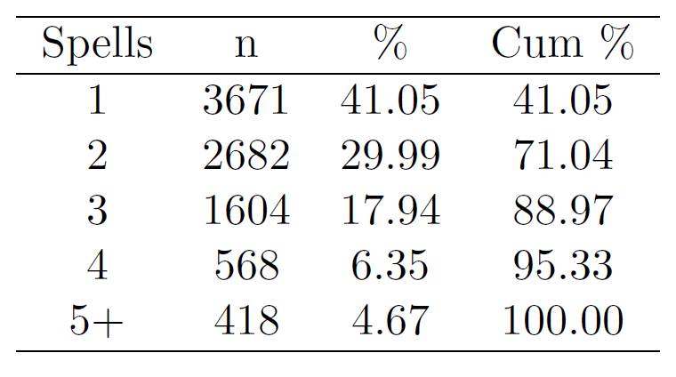

## Results: Sequence Analysis

### Full-Time Work Clusters (I)

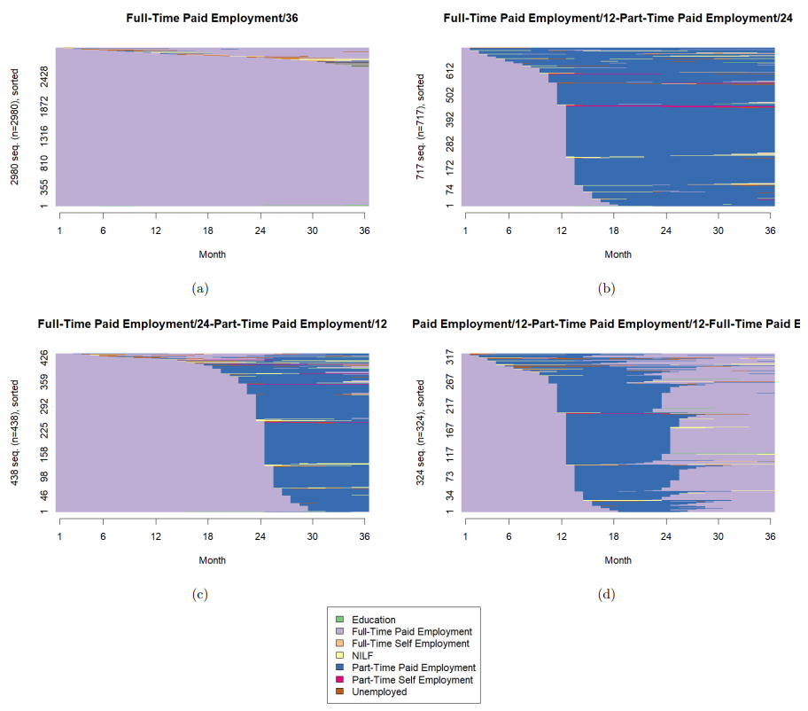

## Results: Sequence Analysis

### Full-Time Work Clusters (II)

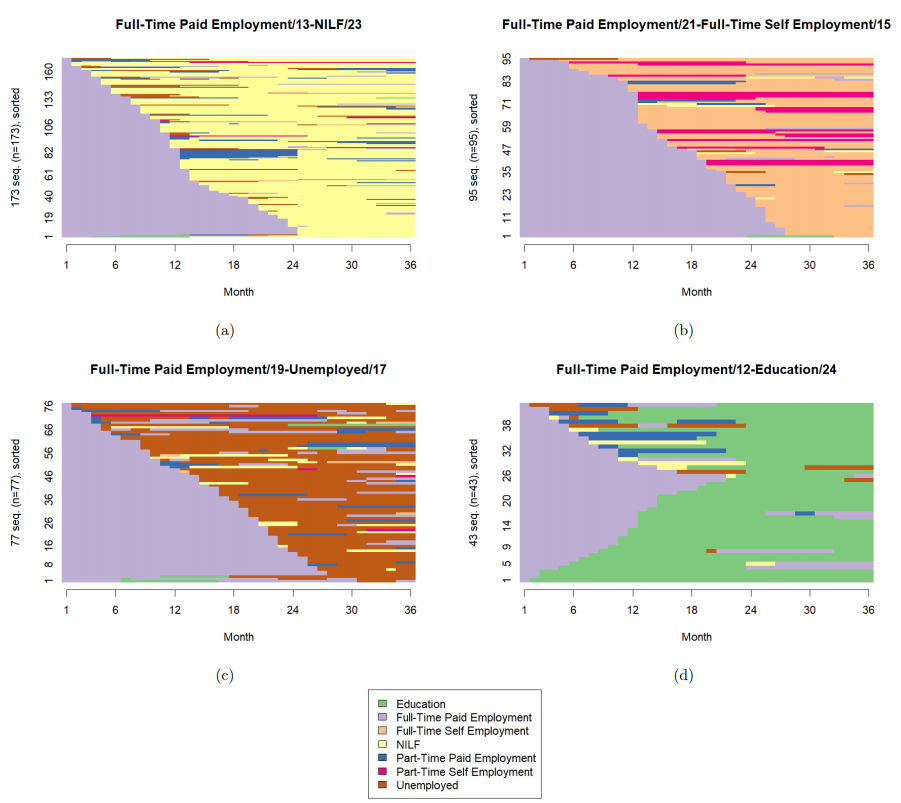

## Results: Sequence Analysis

### Other Status Clusters (I)

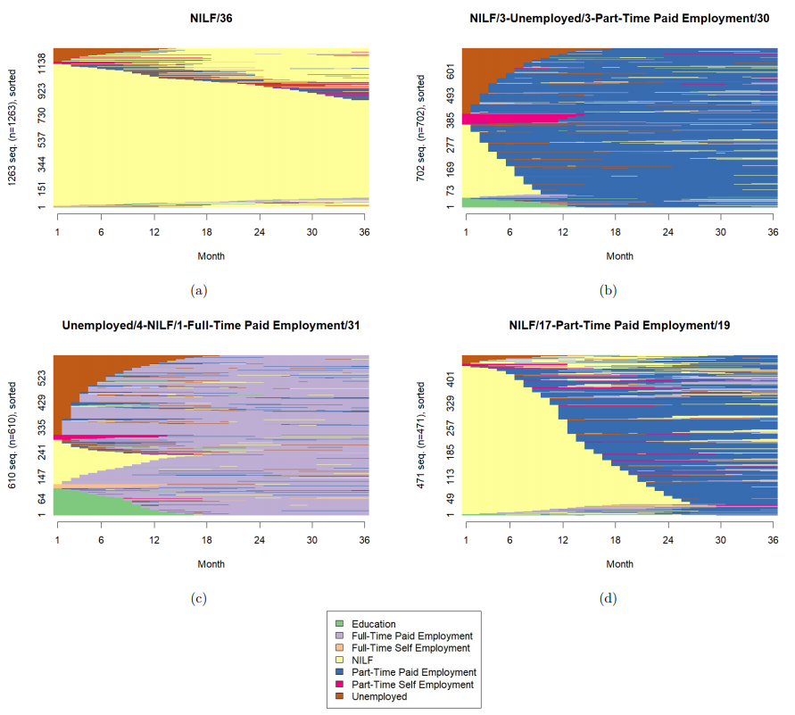

## Results: Sequence Analysis

### Other Status Clusters (II)

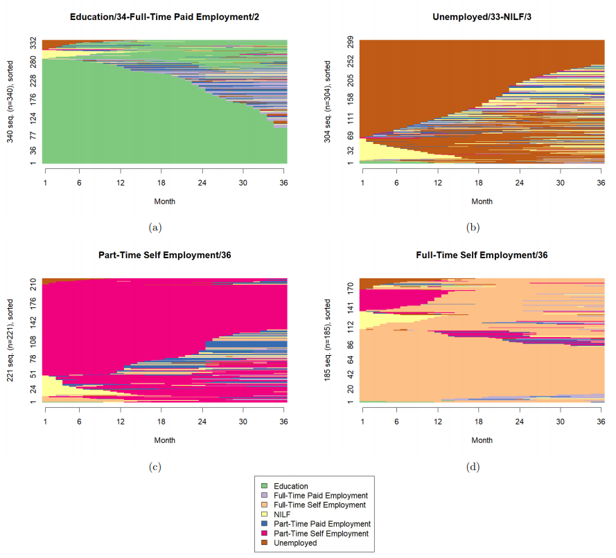

## Results: Sequence Analysis

### Cluster Solution Performance

- Moves into Full-Time Paid Employment:
  - ASW = 0.76
  - R<sup>2</sup> = 0.73
- Moves into Other States:
  - ASW = 0.51
  - R<sup>2</sup> = 0.63

## Results: Sequence Analysis

### Individual Cluster Performance

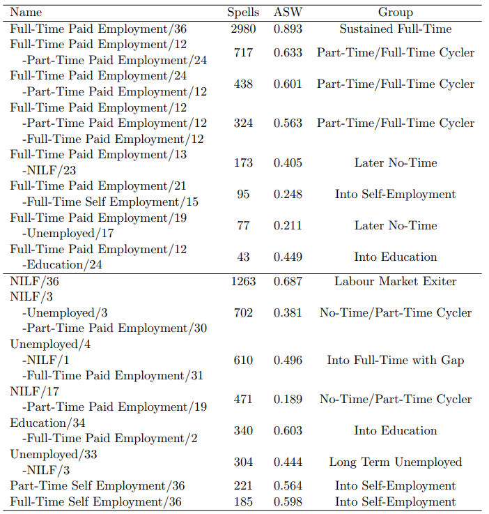

## Results: Sequence Analysis

### Individual Cluster Performance

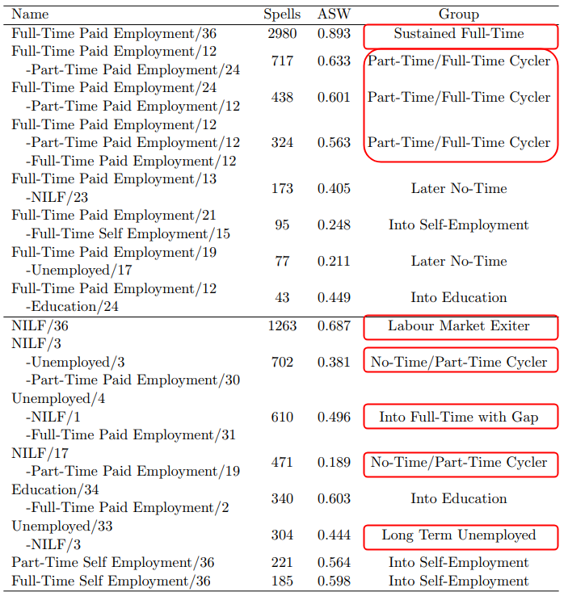

## Results: Cox Models

### Sustained Full-Time Work

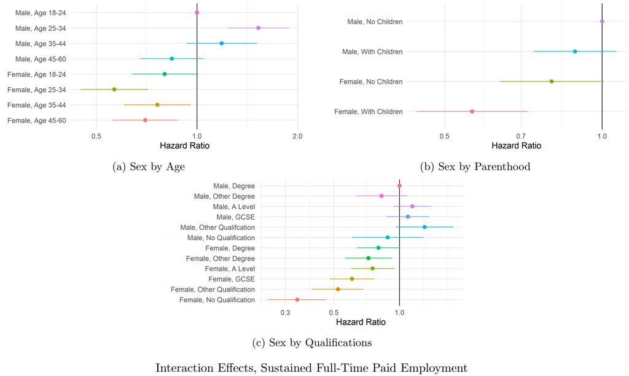

## Results: Cox Models

### Part-Time/Full-Time Cycling

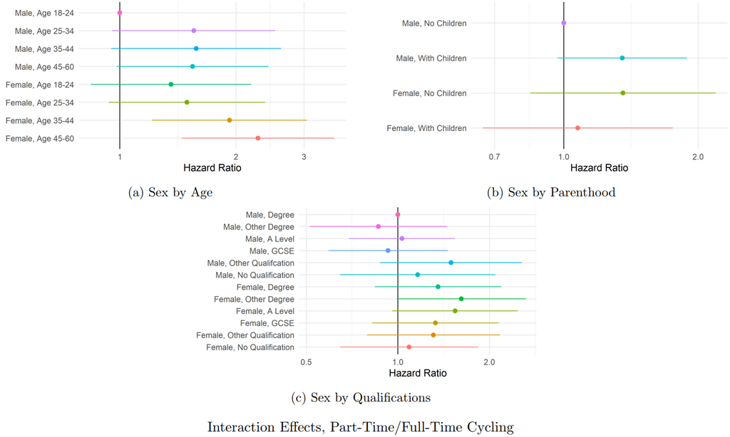

## Results: Cox Models

### Any Move into Full-Time Work

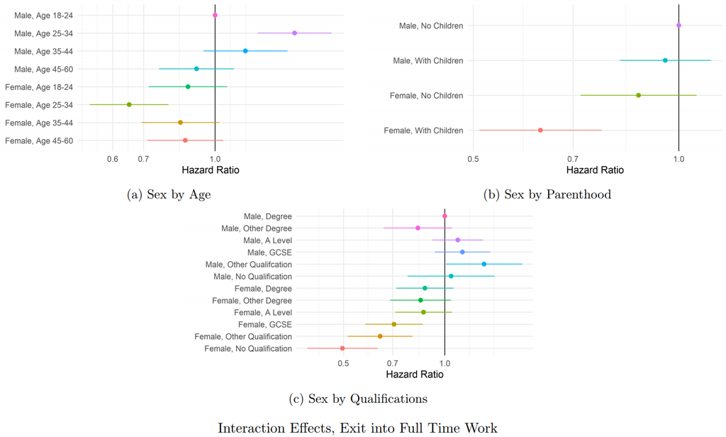

## Results: Cox Models

### No-Time/Part-Time Cycling

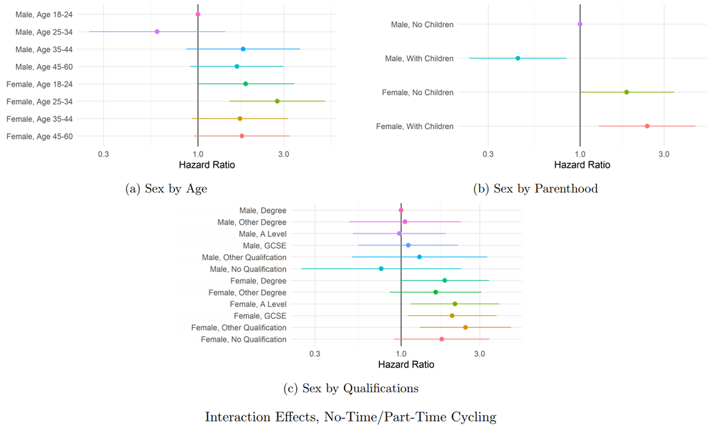

## Results: Cox Models

### Sustained Labour Market Exit

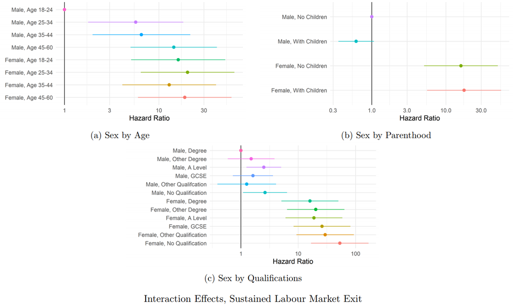

## Results: Cox Models

### Long Term Unemployed

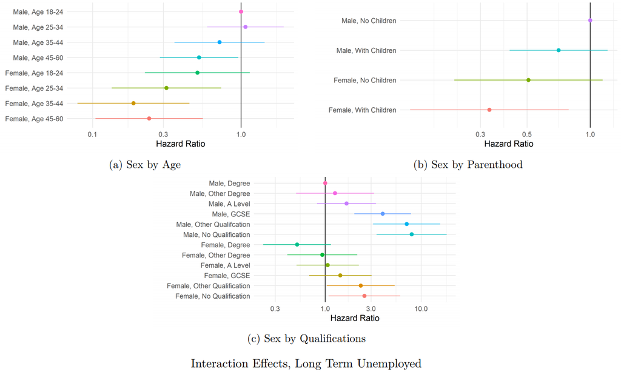

## Results: Cox Models

### Full-Time following Gap

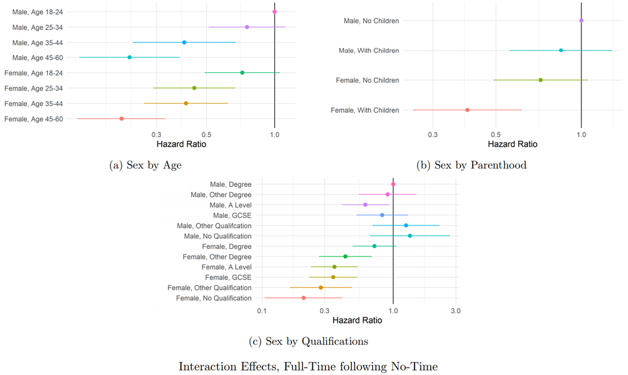

## Results

- Unemployment rate associated with exits into long-term unemployment and no-time/part-time cycling.
  - But, some measurement error in this variable given seam effects in date changes.
- Introduction of National Minimum Wage (NMW) associated with exits into sustained full-time work and part-time/full-time cycling, but also long-term unemployment.
  - Recent review of effects of NMW notes little evidence of strong negative effects on hours (Low Pay Commission, 2019).
  - Results consistent with increase in hours for some individuals (possibly due to price effects) but lower employment for others.
  - But, effects may be biased in this direction, so unclear whether this is spurious.
    - Indeed, effects positive for all six groups (though insignificant for some).
- No consistent associations with ethnicity found.

## Summary

- Some of the effect sizes are substantial.
- Differences across characteristics more pronounced when looking at trajectory, rather than initial transition.
  - Women less likely to exit into sustained full-time employment, but not less likely to cycle.
- Results show value of sequence analysis approach.

## Limitations

- Sample is biased
  - How to get around this?
- Measurement issues in the data
  - Date of hours change not collected
  - Inconsistencies
  - Self-report data
- Heterogeneity within clusters, similarity between.
  - Associations may be driven by atypical individuals (Piccarreta and Studer, In Press).
  - Different dissimilarity and clustering measures could given different results.
- Few variables included in models.
- Explored part-time paid employment but self-employment still interesting.

## References

- Cai, L. (2014). State-dependence and stepping-stone effects of low-pay employment in Australia. Economic Record, 90(291), 486-506. https://doi.org/10.1111/1475-4932.12139
- Cai, L., Law, V., & Bathgate, M. (2014). Is part-time employment a stepping stone to full-time employment? Economic Record, 90(291), 462-485. https://doi.org/10.1111/1475-4932.12120
- Cai, L., Mavromaras, K., & Sloane, P. (2018). Low Paid Employment in Britain: Estimating State-Dependence and Stepping Stone Effects. Oxford Bulletin of Economics and Statistics, 80(2), 283-326. https://doi.org/10.1111/obes.12197
- Cappellari, L., & Jenkins, S. P. (2008a). Estimating low pay transition probabilities accounting for endogenous selection mechanisms. Journal of the Royal Statistical Society. Series C: Applied Statistics, 57(2), 165-186. https://doi.org/10.1111/j.1467-9876.2007.00607.x
- Cappellari, L., & Jenkins, S. P. (2008b). Transitions between unemployment and low pay. In Research in Labor Economics (Vol. 28, pp. 57-79). https://doi.org/10.1016/S0147-9121(08)28003-9

## References

- Fok, Y. K., Scutella, R., & Wilkins, R. (2015). The Low-Pay No-Pay Cycle: Are There Systematic Differences across Demographic Groups? Oxford Bulletin of Economics and Statistics, 77(6), 872-896. https://doi.org/10.1111/obes.12084
- Gabadinho, A., Ritschard, G., Müller, N. S., & Studer, M. (2015). Analyzing and Visualizing State Sequences in R with TraMineR . Journal of Statistical Software, 40(4). https://doi.org/10.18637/jss.v040.i04
- Joseph Rowntree Foundation. (2018). UK Poverty 2018. Retrieved from https://www.jrf.org.uk/report/uk-poverty-2018
- Kaufman, L., & Rousseeuw, P. J. (1990). Finding Groups in Data: An Introduction to Cluster Analysis. John Wiley & Sons, Inc. https://doi.org/10.1002/9780470316801
- Low Pay Commission. (2019). 20 year of the National Minimum Wage. Retreived from https://www.gov.uk/government/publications/20-years-of-the-national-minimum-wage
- Piccarreta, R., & Studer, M. (In Press). Holistic analysis of the life course: Methodological challenges and new perspectives. Advances in Life Course Research. https://doi.org/10.1016/j.alcr.2019.04.005

## References

- Resolution Foundation. (2017). The Great Escape? Low pay and progression in the UK’s labour market. Retrieved from https://www.resolutionfoundation.org/app/uploads/2017/10/Great-Escape-final-report.pdf
- Resolution Foundation. (2019). Low Pay Britain 2019. Retrieved from https://www.resolutionfoundation.org/publications/low-pay-britain-2019/
- Stewart, M. B. (2007). The interrelated dynamics of unemployment and low-wage employment. Journal of Applied Econometrics, 22(3), 511-531. https://doi.org/10.1002/jae.922
- Studer, M. (2013). WeightedCluster Library Manual: A practical guide to creating typologies of trajectories in the social sciences with R. LIVES Working Papers, 1–34. https://doi.org/10.12682/lives.2296-1658.2013.24
- Studer, M., & Ritschard, G. (2016). What matters in differences between life trajectories: A comparative review of sequence dissimilarity measures. Journal of the Royal Statistical Society. Series A: Statistics in Society, 179(2), 481-511. https://doi.org/10.1111/rssa.12125

## References

- Studer, M., Struffolino, E., & Fasang, A. E. (2018). Estimating the Relationship between Time-varying Covariates and Trajectories: The Sequence Analysis Multistate Model Procedure. Sociological Methodology, 48(1), 103-135. https://doi.org/10.1177/0081175017747122
- Therneau, T. M. (2019). coxme v.2.2-10: Mixed Effects Cox Models.